# IBD Analysis - Reviewer Questions

Kevin Williams

January 31, 2021

## Introduction

This is a brief workflow highlighting the follow-up analysis to address reviewer concerns related to the pending manuscript, *“Disparities persist in inclusion of female, pregnant, lactating, and older individuals in inflammatory bowel disease clinical trials”* **(Rabinowitz, Silver et al.)**. Where appropriate, samples of the exact R syntax used will be displayed, along with the corresponding output (tabular data, graphical plots, maps, etc.).

### Main Questions

- What is the distribution of IBD clinical trials by “Phase?”
- For Phase 3 and Phase 4 IBD clinical trials, how many included pregnant subjects?

#### Task 1: Remediate the R data frame, *IBD2* to include a factor variable called *PHASES2* - a recasting of the *PHASES* variable as a factor with five levels, including NA values

```r
require(broom)
require(dplyr)

IBD3  <-
    IBD2 %>%
    select( CATEGORY, PHASES, ANALYZED, FEMALES, PREGNANT_EXCL) %>%
    mutate( PHASES = ifelse(is.na(PHASES), 0, PHASES)) %>%
    mutate( PHASES2 = factor( PHASES,  levels= c(1,2,3,4,0))) %>%
    mutate( PHASES2 = recode_factor( PHASES2, '1'= 'P1', '2'= 'P2', '3' = 'P3', '4' = 'P4', '0' = 'PNA', .ordered = T) )
```

Here’s a glimpse of the structure of the resulting dataset `IBD3`:

```r
glimpse(IBD3)
```

```
## Rows: 146
## Columns: 6
## $ CATEGORY      <fct> 1. CD, 4. COMBO, 4. COMBO, 1. CD, 2. UC, 1. CD, 2. UC, 1…
## $ PHASES        <dbl> 0, 2, 2, 3, 2, 3, 2, 2, 2, 3, 2, 4, 1, 3, 3, 2, 2, 4, 2,…
## $ ANALYZED      <dbl> 99, 89, 50, 54, 36, 147, 50, 8, 124, 250, 66, 34, 58, 64…
## $ FEMALES       <dbl> 63, 39, 29, 24, 14, 64, 22, 1, 52, 145, 25, 13, 31, 305,…
## $ PREGNANT_EXCL <chr> "Y", "N", "Y", "Y", "Y", "N", "N", "Y", "Y", "Y", "Y", "…
## $ PHASES2       <ord> PNA, P2, P2, P3, P2, P3, P2, P2, P2, P3, P2, P4, P1, P3,…
```

#### Task 2: Create cross-tabulations that show the distribution of studies by values of the *PHASES2* factor variable.

```r
require(gmodels)

#Inlcudes Phases with an NA value (no assignment)

CrossTable(IBD3$PHASES2, IBD3$PREGNANT_EXCL, prop.chisq=F, prop.t=F)  #rows then/over columns
```

```
##
##
##    Cell Contents
## |-------------------------|
## |                       N |
## |           N / Row Total |
## |           N / Col Total |
## |-------------------------|
##
##
## Total Observations in Table:  146
##
##
##              | IBD3$PREGNANT_EXCL
## IBD3$PHASES2 |         N |         Y | Row Total |
## -------------|-----------|-----------|-----------|
##           P1 |         4 |         4 |         8 |
##              |     0.500 |     0.500 |     0.055 |
##              |     0.068 |     0.046 |           |
## -------------|-----------|-----------|-----------|
##           P2 |        17 |        31 |        48 |
##              |     0.354 |     0.646 |     0.329 |
##              |     0.288 |     0.356 |           |
## -------------|-----------|-----------|-----------|
##           P3 |        30 |        35 |        65 |
##              |     0.462 |     0.538 |     0.445 |
##              |     0.508 |     0.402 |           |
## -------------|-----------|-----------|-----------|
##           P4 |         3 |         8 |        11 |
##              |     0.273 |     0.727 |     0.075 |
##              |     0.051 |     0.092 |           |
## -------------|-----------|-----------|-----------|
##          PNA |         5 |         9 |        14 |
##              |     0.357 |     0.643 |     0.096 |
##              |     0.085 |     0.103 |           |
## -------------|-----------|-----------|-----------|
## Column Total |        59 |        87 |       146 |
##              |     0.404 |     0.596 |           |
## -------------|-----------|-----------|-----------|
##
##
```

```r
#Includes Phases only with a value (NA values excluded)

IBD3A <-
IBD3 %>% filter( PHASES2 != "PNA")
  CrossTable( IBD3A$PHASES2, IBD3A$PREGNANT_EXCL, prop.chisq=F, prop.t=F)  #rows then/over columns
```

```
##
##
##    Cell Contents
## |-------------------------|
## |                       N |
## |           N / Row Total |
## |           N / Col Total |
## |-------------------------|
##
##
## Total Observations in Table:  132
##
##
##               | IBD3A$PREGNANT_EXCL
## IBD3A$PHASES2 |         N |         Y | Row Total |
## --------------|-----------|-----------|-----------|
##            P1 |         4 |         4 |         8 |
##               |     0.500 |     0.500 |     0.061 |
##               |     0.074 |     0.051 |           |
## --------------|-----------|-----------|-----------|
##            P2 |        17 |        31 |        48 |
##               |     0.354 |     0.646 |     0.364 |
##               |     0.315 |     0.397 |           |
## --------------|-----------|-----------|-----------|
##            P3 |        30 |        35 |        65 |
##               |     0.462 |     0.538 |     0.492 |
##               |     0.556 |     0.449 |           |
## --------------|-----------|-----------|-----------|
##            P4 |         3 |         8 |        11 |
##               |     0.273 |     0.727 |     0.083 |
##               |     0.056 |     0.103 |           |
## --------------|-----------|-----------|-----------|
##  Column Total |        54 |        78 |       132 |
##               |     0.409 |     0.591 |           |
## --------------|-----------|-----------|-----------|
##
##
```

#### Task 3: Create cross-tabulations based on a subset of the values of the *PHASES2* factor variable - one that includes *only* Phase 3 & Phase 4 clinicial trials

```r
require(gmodels)
require(sjPlot)


IBD3B <-
IBD3 %>% filter( PHASES2 %in% c('P3', 'P4')) %>% droplevels()
  CrossTable( IBD3B$PHASES2, IBD3B$PREGNANT_EXCL, prop.chisq=F, prop.t=F)  #rows then/over columns
```

```
##
##
##    Cell Contents
## |-------------------------|
## |                       N |
## |           N / Row Total |
## |           N / Col Total |
## |-------------------------|
##
##
## Total Observations in Table:  76
##
##
##               | IBD3B$PREGNANT_EXCL
## IBD3B$PHASES2 |         N |         Y | Row Total |
## --------------|-----------|-----------|-----------|
##            P3 |        30 |        35 |        65 |
##               |     0.462 |     0.538 |     0.855 |
##               |     0.909 |     0.814 |           |
## --------------|-----------|-----------|-----------|
##            P4 |         3 |         8 |        11 |
##               |     0.273 |     0.727 |     0.145 |
##               |     0.091 |     0.186 |           |
## --------------|-----------|-----------|-----------|
##  Column Total |        33 |        43 |        76 |
##               |     0.434 |     0.566 |           |
## --------------|-----------|-----------|-----------|
##
##
```

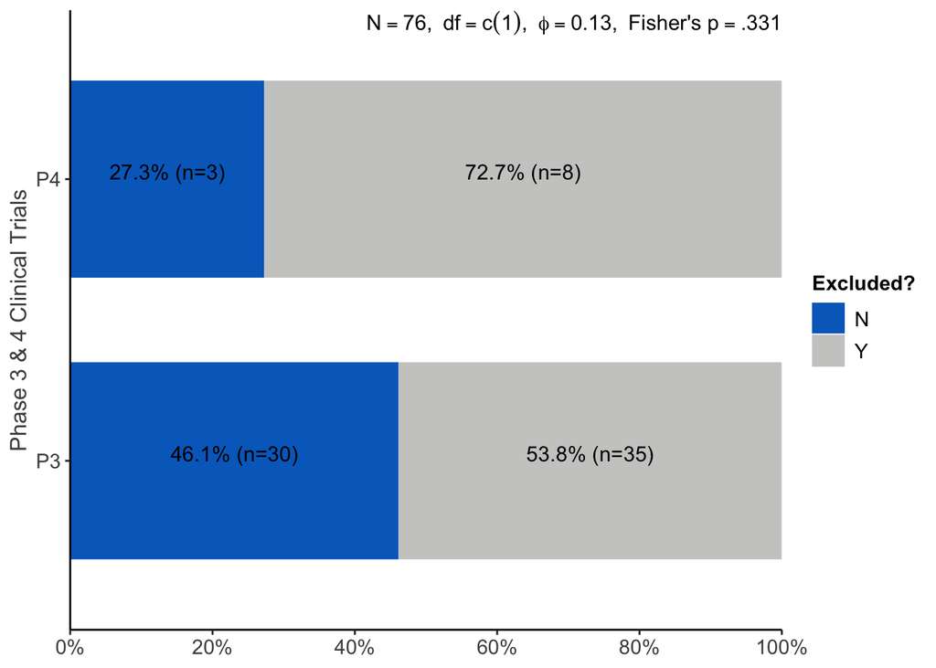

```r
#SJPlot cross tabulation with Chi-Square/df

plot_xtab(IBD3B$PHASES2, IBD3B$PREGNANT_EXCL, margin = "row",
          bar.pos = "stack", coord.flip = TRUE,
          axis.titles = c('Phase 3 & 4 Clinical Trials'),
          legend.title= "Excluded?",
          geom.colors = c("#006cc5","#cbcccb"),
          show.summary = TRUE )+
  set_theme(base= theme_classic())
```

#### Task 4: Previously run cross-tabulations provide only frequency statistics for trials. In case summary stats are required based on the number of *participants,* create a series of summary tables that provide this metric.

```r
require(kableExtra)


IBD3_SUMMARY <-

    IBD3 %>% group_by( PHASES2 ) %>%
      summarise( COUNT = n(),
                 SUBJECTS = sum(ANALYZED)) %>%
      mutate( PCT_N = percent(COUNT / sum(COUNT)),
              PCT_SUBJ = percent(SUBJECTS / sum(SUBJECTS))) %>%  tibble::as_tibble()

IBD3A_SUMMARY <-

  IBD3A %>% group_by( PHASES2 ) %>%
  summarise( COUNT = n(),
             SUBJECTS = sum(ANALYZED)) %>%
  mutate( PCT_N = percent(COUNT / sum(COUNT)),
          PCT_SUBJ = percent(SUBJECTS / sum(SUBJECTS))) %>%   tibble::as_tibble()


IBD3B_SUMMARY <-

  IBD3B %>% group_by( PHASES2, PREGNANT_EXCL ) %>%
  summarise( COUNT = n(),
             SUBJECTS = sum(ANALYZED)) %>%
  mutate( PCT_N = percent(COUNT / sum(COUNT)),
          PCT_SUBJ = percent(SUBJECTS / sum(SUBJECTS))) %>%   tibble::as_tibble()
kbl(IBD3_SUMMARY, booktabs = T, format= "html",
    caption = "<center><strong>IBD Clinical Trials by Phase Type</strong></center>",
    align= c('l','r','r','r','r'), escape=F,
    col.names = linebreak(c("Phase", "Trials<br>N", "Subjects<br>N", "Trials<br>Pct", "Subjects<br>Pct"))) %>%

  kable_styling(full_width = F, "hover") %>% column_spec(1, width = "4cm") %>%
  scroll_box(height = "6in")
```

**IBD Clinical Trials by Phase Type**

| Phase | Trials N | Subjects N | Trials Pct | Subjects Pct |
| --- | --- | --- | --- | --- |
| P1 | 8 | 297 | 5.48% | 0.59% |
| P2 | 48 | 6379 | 32.88% | 12.71% |
| P3 | 65 | 31519 | 44.52% | 62.80% |
| P4 | 11 | 1687 | 7.53% | 3.36% |
| PNA | 14 | 10306 | 9.59% | 20.53% |

```r
kbl(IBD3A_SUMMARY, booktabs = T, format= "html",
    caption = "<center><strong>IBD Clinical Trials by Phase Type (NO NA)</strong></center>",
    align= c('l','r','r','r','r'), escape=F,
    col.names = linebreak(c("Phase", "Trials<br>N", "Subjects<br>N", "Trials<br>Pct", "Subjects<br>Pct"))) %>%

  kable_styling(full_width = F, "hover") %>% column_spec(1, width = "4cm") %>%
  scroll_box(height = "6in")
```

**IBD Clinical Trials by Phase Type (NO NA)**

| Phase | Trials N | Subjects N | Trials Pct | Subjects Pct |
| --- | --- | --- | --- | --- |
| P1 | 8 | 297 | 6.06% | 0.74% |
| P2 | 48 | 6379 | 36.36% | 15.99% |
| P3 | 65 | 31519 | 49.24% | 79.03% |
| P4 | 11 | 1687 | 8.33% | 4.23% |

```r
kbl(IBD3B_SUMMARY, booktabs = T, format= "html",
    caption = "<center><strong>IBD Phase 3/4 Clinical Trials by Pregnancy Status</strong></center>",
    align= c('l','c','r','r','r','r'), escape=F,
    col.names = linebreak(c("Phase", "Excludes<br>Pregnant?", "Count<br>N", "Subjects<br>N", "Trials<br>Pct", "Subjects<br>Pct"))) %>%

  kable_styling(full_width = F, "hover") %>% column_spec(1, width = "4cm") %>%
  scroll_box(height = "6in")
```

**IBD Phase 3/4 Clinical Trials by Pregnancy Status**

| Phase | Excludes Pregnant? | Count N | Subjects N | Trials Pct | Subjects Pct |
| --- | --- | --- | --- | --- | --- |
| P3 | N | 30 | 16870 | 46.15% | 53.52% |
| P3 | Y | 35 | 14649 | 53.85% | 46.48% |
| P4 | N | 3 | 124 | 27.27% | 7.35% |
| P4 | Y | 8 | 1563 | 72.73% | 92.65% |